# R Notebook

| Title: “IST707 HW6 Use Classification Algortithms for handwriting recognition” |
| --- |
| Name: Sathish Kumar Rajendiran |
| Date: 08/25/2020 |

Exercise: compare naïve Bayes , decision tree, SVMs, kNN, and Random Forest algorithmse for handwriting recognition.

In this homework assignment, you are going to use the decision tree algorithm to solve the disputed essay problem. Last week you used clustering techniques to tackle this problem.

Organize your report using the following template:

Section 1: Introduction Briefly describe the classification problem and general data preprocessing. Note that some data preprocessing steps maybe specific to a particular algorithm. Report those steps under each algorithm section.

Section 2: Decision tree Build a decision tree model. Tune the parameters, such as the pruning options, and report the 3-fold CV accuracy.

Section 3: Naïve Bayes Build a naïve Bayes model. Tune the parameters, such as the discretization options, to compare results.

Section 4: kNN Build a kNN model. Tune the parameters, such as the discretization options, to compare results.

Section 5: SVM Build a SVM model. Tune the parameters, such as the discretization options, to compare results.

Section 6: Random Forest Build a Random Forest model. Tune the parameters, such as the discretization options, to compare results.

Section 7: Algorithm performance comparison Compare the results from the two algorithms. Which one reached higher accuracy? Which one runs faster? Can you explain why?

Section 8: Kaggle test result (1 extra point) Report the test accuracy for the naïve Bayes and decision tree models. Discuss whether overfitting occurs in these models.

Grading rubrics: 1. Are the models constructed correctly? 2. Is the result analysis conclusion convincing? 3. Is sufficient details provided for others to repeat the analysis? 4. Does the analysis include irrelevant content? 5. Successful submission to Kaggle?

```r
# import libraries
#create a function to ensure the libraries are imported
EnsurePackage <- function(x){
  x <- as.character(x)
    if (!require(x,character.only = TRUE)){
      install.packages(pkgs=x, repos = "http://cran.us.r-project.org")
      require(x, character.only = TRUE)
    }
  }
# usage example, to load the necessary library for further processing...
```

```r
EnsurePackage("class") # kNN
EnsurePackage("e1071")
EnsurePackage("sqldf")
EnsurePackage("FactoMineR")
EnsurePackage("rpart.plot")  # Decision Tree
EnsurePackage("randomForest") # Random Forest
EnsurePackage("caret") # Plot ConfusionMatrix
EnsurePackage("ggplot2")
EnsurePackage("kernlab")
EnsurePackage("dplyr")
EnsurePackage("RColorBrewer")
EnsurePackage("stringr")
cat("All Packages are available")
```

```
All Packages are available
```

```r
  # Preview the structure
  str(digitTrainDF)
```

```
'data.frame':   42000 obs. of  785 variables:
 $ label   : Factor w/ 10 levels "0","1","2","3",..: 2 1 2 5 1 1 8 4 6 4 ...
 $ pixel0  : int  0 0 0 0 0 0 0 0 0 0 ...
 $ pixel1  : int  0 0 0 0 0 0 0 0 0 0 ...
 $ pixel2  : int  0 0 0 0 0 0 0 0 0 0 ...
 $ pixel3  : int  0 0 0 0 0 0 0 0 0 0 ...
 $ pixel4  : int  0 0 0 0 0 0 0 0 0 0 ...
 $ pixel5  : int  0 0 0 0 0 0 0 0 0 0 ...
 $ pixel6  : int  0 0 0 0 0 0 0 0 0 0 ...
 $ pixel7  : int  0 0 0 0 0 0 0 0 0 0 ...
 $ pixel8  : int  0 0 0 0 0 0 0 0 0 0 ...
 $ pixel9  : int  0 0 0 0 0 0 0 0 0 0 ...
 $ pixel10 : int  0 0 0 0 0 0 0 0 0 0 ...
 $ pixel11 : int  0 0 0 0 0 0 0 0 0 0 ...
 $ pixel12 : int  0 0 0 0 0 0 0 0 0 0 ...
```

[output cut: 86 more lines]

```r
   dim(test_set)
```

```
[1] 8400  785
```

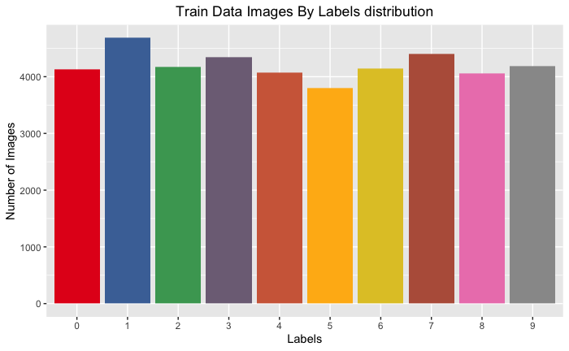

```r
# # compare number of images by labels
  x <- data.frame(table(digitTrainDF$label))
  colourCount = length(unique(digitTrainDF$label))
  getPalette = colorRampPalette(brewer.pal(9, "Set1"))

  gp_all <- ggplot(x, aes(x=Var1, y=Freq)) +   geom_bar(position="dodge",stat = "identity", fill=getPalette(colourCount))
  gp_all <- gp_all + ggtitle("Train Data Images By Labels distribution") + xlab("Labels") + ylab("Number of Images")
  gp_all <- gp_all +  theme(plot.title = element_text(hjust = 0.5),axis.title = element_text())
  gp_all
```

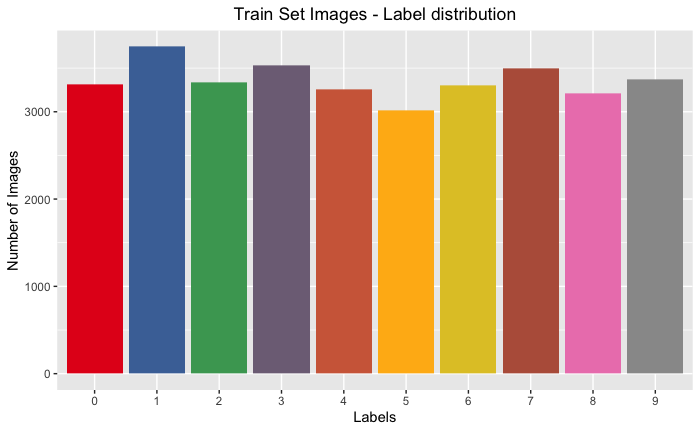

```r
# # compare number of images by labels
  tn_set <- data.frame(table(train_set$label))
  colourCount = length(unique(train_set$label))
  getPalette = colorRampPalette(brewer.pal(9, "Set1"))

  gp_tnset <- ggplot(tn_set, aes(x=Var1, y=Freq)) +   geom_bar(position="dodge",stat = "identity", fill=getPalette(colourCount))
  gp_tnset <- gp_tnset + ggtitle("Train Set Images - Label distribution") + xlab("Labels") + ylab("Number of Images")
  gp_tnset <- gp_tnset +  theme(plot.title = element_text(hjust = 0.5),axis.title = element_text())
  gp_tnset
```

```r
 # compare number of images by labels
  tst_set <- data.frame(table(test_set$label))
  colourCount = length(unique(test_set$label))
  getPalette = colorRampPalette(brewer.pal(9, "Set1"))

  gp_tst_set <- ggplot(tst_set, aes(x=Var1, y=Freq)) +   geom_bar(position="dodge",stat = "identity",
                                                                  fill=getPalette(colourCount))
  gp_tst_set <- gp_tst_set + ggtitle("Test Set Images - Label distribution") + xlab("Labels") + ylab("Number of Images")
  gp_tst_set <- gp_tst_set +  theme(plot.title = element_text(hjust = 0.5),axis.title = element_text())
  gp_tst_set
```

[output not shown]

```r
#Load Test Data CSV as Validation data frame
  validation_data <- "/Users/sathishrajendiran/Documents/R/HW6/digit_test.csv"
  digitValidationDF <- data.frame(read.csv(validation_data,na.strings=c(""," ","NA"))
                                  ,stringsAsFactors=FALSE)
  dim(digitValidationDF) #28000   784
  digitValidationDF[,"label"] <- ''
  digitValidationDF$label <- as.factor(digitValidationDF$label)
  digitValidationDF <- digitValidationDF[,c(which(colnames(digitValidationDF)=="label")
                                            ,which(colnames(digitValidationDF)!="label"))]
  # Preview top few rows
  head(digitValidationDF)
```

```r
# Section 2: Build and tune decision tree models

  # grow tree
  rtree <- rpart(label~. ,data=train_set, method='class', cp=0,minsplit = 1, maxdepth = 5)

  #summarize rtree values
  summary(rtree)
  plotcp(rtree) # plot cross-validation results
  printcp(rtree) # plot cross-validation results

  # Plot tree | lets Plot decision trees
  rpart.plot(rtree,main="Classification Tree for MNISDigit Tokenizer", extra= 102) # plot decision tree
  rsq.rpart(rtree) # plot approximate R-squared and relative error for different splits (2 plots)
```

```r
# Section 3: Prediction | Test Phase

  cat("\nTrain Data Images:")
  table(digitTrainDF$label)

  cat("\nTrain_Set - Images by Labels:")
  table(train_set$label)

  cat("\nTest_Set - Images by Labels:")
  table(test_set$label)

  predict_unseen <- predict(rtree, test_set, type = 'class')
  # predict_unseen
  table_test_matrix <- table(test_set$label, predict_unseen)
  cat("\n\nPrediction results : Confusion Matrix \n\n")
  # table_mat
  confusionMatrix(table_test_matrix)
```

```r
str(digitTrainDF)
str(test_set)
str(train_set)
str(digitValidationDF)
```

```r
# Section 3: Prediction | Validation Phase
  cat("\nTest Data Images:")
  table(digitValidationDF$label)

  cat("\nTrain Data Images:")
  table(digitTrainDF$label)

  cat("\nTrain_Set - Images by Labels:")
  table(train_set$label)

  cat("\nTest_Set - Images by Labels:")
  table(test_set$label)

  predict_final <- predict(rtree, digitValidationDF, type = 'class')
  table_final <- table(digitValidationDF$label, predict_final)
  cat("\n\nPrediction results : \n\n")
  table_final
```

```r
  #View the final validation results and export to csv
  predict_finaldf <- data.frame(predict_final)
  cat("\n\nPrediction results by Label : \n\n")
  View(predict_finaldf)

  #Export to CSV
  write.csv(x=predict_finaldf, file="/Users/sathishrajendiran/Documents/R/HW6/predict_finaldf.csv")
```

```r
# Random Forest prediction of Digit Tokenizer data
  EnsurePackage("randomForest")

  # View(fedPapersDF1)
  cat("\n All Images by Labels:")
  table(test_set$label)

  fit <- randomForest(y=test_set$label, x=test_set[2:ncol(test_set)], data=test_set, ntree=100
                      , keep.forest=FALSE, importance=TRUE)
  print(fit) # view results
  importance(fit) # importance of each predictor
```

```r
  rf_importance <- data.frame(importance(fit)) # importance of each predictor
  rf_importance
```

```r
pca_digits <- PCA(t(select(digitTrainDF,-label)),ncp=30)
```

```r
digitPCATrainDF <- data.frame(digitTrainDF$label,pca_digits$var$coord)
# percent <- .25
```

```r
dim(digitPCATrainDF)

head(digitPCATrainDF)
```

```r
 colnames(digitPCATrainDF) <- c("label","dim1","dim2","dim3","dim4","dim5","dim6","dim7","dim8","dim9","dim10","dim11","dim12","dim13"
                                ,"dim14","dim15","dim16","dim17","dim18","dim19","dim20","dim21","dim22","dim23","dim24","dim25"
                                ,"dim26","dim27","dim28","dim29","dim30")
str(digitPCATrainDF)
```

```r
# Prepare train and test data from the revised PCA Train dataset.
  sample_size = floor(0.80*nrow(digitPCATrainDF))
  # set seed to ensure you always have same random numbers generated #324 has 100% training accuracy
  train_index = sample(seq_len(nrow(digitPCATrainDF)),size = sample_size)

  pca_train_set =digitPCATrainDF[train_index,] #creates the training dataset with row numbers stored in train_index
  # # table(train_data$author)
  pca_test_set=digitPCATrainDF[-train_index,]  # creates the test dataset excluding the row numbers mentioned in train_index
  # # table(test_data$author)
  #
  cat("\nImages by Labels:")
  table(digitPCATrainDF$label)
  cat("\nTrain_set - Images by Labels:")
  table(pca_train_set$label)
  cat("\nTest_set - Images by Labels:")
  table(pca_test_set$label)
```

```r
# # compare number of images by labels
  pca_x <- data.frame(table(digitPCATrainDF$label))
  colourCount = length(unique(digitPCATrainDF$label))
  getPalette = colorRampPalette(brewer.pal(9, "Set1"))

  pca_gp_all <- ggplot(pca_x, aes(x=Var1, y=Freq)) +   geom_bar(position="dodge",stat = "identity", fill=getPalette(colourCount))
  pca_gp_all <- pca_gp_all + ggtitle("Train Data Images By Labels distribution") + xlab("Labels") + ylab("Number of Images")
  pca_gp_all <- pca_gp_all +  theme(plot.title = element_text(hjust = 0.5),axis.title = element_text())
  pca_gp_all
```

```r
# # compare number of images by labels
  pca_tn_set <- data.frame(table(pca_train_set$label))
  colourCount = length(unique(pca_train_set$label))
  getPalette = colorRampPalette(brewer.pal(9, "Set1"))

  pca_gp_tnset <- ggplot(pca_tn_set, aes(x=Var1, y=Freq)) +   geom_bar(position="dodge",stat = "identity", fill=getPalette(colourCount))
  pca_gp_tnset <- pca_gp_tnset + ggtitle("Train Set Images - Label distribution") + xlab("Labels") + ylab("Number of Images")
  pca_gp_tnset <- pca_gp_tnset +  theme(plot.title = element_text(hjust = 0.5),axis.title = element_text())
  pca_gp_tnset
```

```r
# # compare number of images by labels
  pca_tst_set <- data.frame(table(pca_test_set$label))
  colourCount = length(unique(pca_test_set$label))
  getPalette = colorRampPalette(brewer.pal(9, "Set1"))

  pca_gp_tst_set <- ggplot(pca_tst_set, aes(x=Var1, y=Freq)) +   geom_bar(position="dodge",stat = "identity", fill=getPalette(colourCount))
  pca_gp_tst_set <- pca_gp_tst_set + ggtitle("Test Set Images - Label distribution") + xlab("Labels") + ylab("Number of Images")
  pca_gp_tst_set <- pca_gp_tst_set +  theme(plot.title = element_text(hjust = 0.5),axis.title = element_text())
  pca_gp_tst_set
```

```r
# Section 2: Build and tune decision tree models

  # grow tree
  pca_rtree <- rpart(label~. ,data=pca_train_set, method='class', cp=0,minsplit = 1, maxdepth = 10)

  #summarize rtree values
  summary(pca_rtree)
  plotcp(pca_rtree) # plot cross-validation results
  printcp(pca_rtree) # plot cross-validation results

  # Plot tree | lets Plot decision trees
  rpart.plot(pca_rtree,main="Classification Tree for MNISDigit Tokenizer after PCA", extra= 102) # plot decision tree
  rsq.rpart(pca_rtree) # plot approximate R-squared and relative error for different splits (2 plots)
```

```r
# Section 3: Prediction | Test Phase

  cat("\nTrain Data Images:")
  table(digitPCATrainDF$label)

  cat("\nTrain_Set - Images by Labels:")
  table(pca_train_set$label)

  cat("\nTest_Set - Images by Labels:")
  table(pca_test_set$label)

  pca_predict_unseen <- predict(pca_rtree, pca_test_set, type = 'class')
  # predict_unseen
  pca_table_test_matrix <- table(pca_test_set$label, pca_predict_unseen)
  cat("\n\nPrediction results : Confusion Matrix \n\n")
  # table_mat
  confusionMatrix(pca_table_test_matrix)
```

```r
# Section 3: Prediction | Validation Phase
  cat("\nTest Data Images:")
  table(digitPCATrainDF$label)

  cat("\nTrain Data Images:")
  table(digitTrainDF$label)

  cat("\nTrain_Set - Images by Labels:")
  table(pca_train_set$label)

  cat("\nTest_Set - Images by Labels:")
  table(pca_test_set$label)

  pca_predict_final <- predict(rtree, digitValidationDF, type = 'class')
  pca_table_final <- table(digitValidationDF$label, pca_predict_final)
  cat("\n\nPrediction results : \n\n")
  pca_table_final
```

```r
 #View the final validation results and export to csv
  pca_predict_finaldf <- data.frame(pca_predict_final)
  cat("\n\nPrediction results by Label : \n\n")
  View(pca_predict_finaldf)

  #Export to CSV
  write.csv(x=pca_predict_finaldf, file="/Users/sathishrajendiran/Documents/R/HW6/pca_predict_finaldf.csv")
```

```r
# kNN - Training the KNN model
pca_training_kNN <- trainControl(method = "repeatedcv", number = 10, repeats = 3)
set.seed(3033)
pca_knn_fit <- train(label ~ ., data = pca_train_set, method = "knn", trControl=pca_training_kNN, preProcess = c("center", "scale")
                     , tuneLength = 10)
pca_knn_fit
```

```r
#kNN - Prediction
pca_knn_test_pred <- predict(pca_knn_fit, newdata =pca_test_set)
View(data.frame(pca_knn_test_pred, pca_test_set$label))
summary(pca_knn_test_pred)
```

```r
#SVM - Building the Model | Linear Kernel

pca_svm_model <- svm(label ~ ., data = pca_train_set, kernel= 'linear', cost =100, scale = FALSE, Probability = TRUE, Cross = 3,type = 'C')
summary(pca_svm_model)
```

```r
#SVM - Prediction

pca_svmPred <- predict(pca_svm_model, pca_test_set, type = 'prob')
pca_svmPred <- as.data.frame(pca_svmPred)
colnames(pca_svmPred) <- 'results'


svmResults <- pca_test_set %>% select(label) %>% bind_cols(pca_svmPred) %>% mutate(real = factor(as.character(str_remove(label, 'V'))), prediction = factor(as.character(str_remove(results, 'V'))))

confusionMatrix(svmResults$real, svmResults$prediction) #92%
```

```r
#SVM - Building the Model | Linear linear | cost 10
pca_svm_model_linear1 <- svm(label ~ ., data = pca_train_set, kernel= 'linear', cost =100, scale = FALSE,
                             Probability = TRUE, Cross = 3,type = 'C')
summary(pca_svm_model_linear1)

#SVM - Prediction
pca_svmPred_linear1 <- predict(pca_svm_model_linear1, pca_test_set, type = 'prob')

#Plot the results
pca_svmPred_linear1 <- as.data.frame(pca_svmPred_linear1)
colnames(pca_svmPred_linear1) <- 'results'
svmResults_linear1 <- pca_test_set %>% select(label) %>% bind_cols(pca_svmPred_linear1) %>% mutate(real = factor(as.character(str_remove(label, 'V'))),
                                                                                                   prediction = factor(as.character(str_remove(results, 'V'))))

#Build Confusion matrix
confusionMatrix(svmResults_linear1$real, svmResults_linear1$prediction) #92%
```

```r
#SVM - Building the Model | Radial Kernel | cost 10
pca_svm_model_radial1 <- svm(label ~ ., data = pca_train_set, kernel= 'radial', cost =10, scale = FALSE, Probability = TRUE, Cross = 3,type = 'C')
summary(pca_svm_model_radial1)

#SVM - Prediction

pca_svmPred_radial1 <- predict(pca_svm_model_radial1, pca_test_set, type = 'prob')
pca_svmPred_radial1 <- as.data.frame(pca_svmPred_radial1)
colnames(pca_svmPred_radial1) <- 'results'

svmResults_radial1 <- pca_test_set %>% select(label) %>% bind_cols(pca_svmPred_radial1) %>% mutate(real = factor(as.character(str_remove(label, 'V')))
                                                                                                   , prediction = factor(as.character(str_remove(results, 'V'))))

#Build Confusion matrix
confusionMatrix(svmResults_radial1$real, svmResults_radial1$prediction) #92.42 %
```

```r
#SVM - Building the Model | Radial Kernel | cost 10
pca_svm_model_radial <- svm(label ~ ., data = pca_train_set, kernel= 'radial', cost =100, scale = FALSE, Probability = TRUE, Cross = 3,type = 'C')
summary(pca_svm_model_radial)

#SVM - Prediction

pca_svmPred_radial <- predict(pca_svm_model_radial, pca_test_set, type = 'prob')


#Plot the results
pca_svmPred_radial <- as.data.frame(pca_svmPred_radial)
colnames(pca_svmPred_radial) <- 'results'
svmResults_radial <- pca_test_set %>% select(label) %>% bind_cols(pca_svmPred_radial) %>% mutate(real = factor(as.character(str_remove(label, 'V')))
                                                                                                 , prediction = factor(as.character(str_remove(results, 'V'))))
#Build Confusion matrix
pca_SVM_radialMatrix <- confusionMatrix(svmResults_radial$real, svmResults_radial$prediction) #94.48 %
pca_SVM_radialMatrix
pca_SVM_radialMatrix$overall
```

```r
# # digitValidationDF
# pca_digits_validation <- PCA(t(select(digitValidationDF,-label)),ncp=30)
# digitPCAValidationDF <- data.frame(digitValidationDF$label,pca_digits_validation$var$coord)
# colnames(digitPCAValidationDF) <- c("label","dim1","dim2","dim3","dim4","dim5","dim6","dim7","dim8","dim9","dim10","dim11","dim12","dim13"
#                               ,"dim14","dim15","dim16","dim17","dim18","dim19","dim20","dim21","dim22","dim23","dim24","dim25"
#                               ,"dim26","dim27","dim28","dim29","dim30")
# str(digitPCAValidationDF)
```

```r
#SVM - Building the Model | polynomial polynomial | cost 10
pca_svm_model_polynomial <- svm(label ~ ., data = pca_train_set, kernel= 'polynomial', cost =100, scale = FALSE, Probability = TRUE, Cross = 3,type = 'C')
summary(pca_svm_model_polynomial)

#SVM - Prediction

pca_svmPred_polynomial <- predict(pca_svm_model_polynomial, pca_test_set, type = 'prob')

#Plot the results
pca_svmPred_polynomial <- as.data.frame(pca_svmPred_polynomial)
colnames(pca_svmPred_polynomial) <- 'results'
svmResults_polynomial <- pca_test_set %>% select(label) %>% bind_cols(pca_svmPred_polynomial) %>% mutate(real = factor(as.character(str_remove(label, 'V')))
                                                                                                 , prediction = factor(as.character(str_remove(results, 'V'))))
#Build Confusion matrix
pca_SVM_ploynomialMatrix <- confusionMatrix(svmResults_polynomial$real, svmResults_polynomial$prediction) #94.48 %
pca_SVM_ploynomialMatrix
pca_SVM_ploynomialMatrix$overall
```

```r
#naiveBayes - Building the Model
pca_NB_model <- naiveBayes(label ~ ., data = pca_train_set, cost =100, scale = FALSE, Probability = TRUE, Cross = 3,type = 'C')
summary(pca_NB_model)

#naiveBayes - Prediction

pca_NB_Pred <- predict(pca_NB_model, pca_test_set, type = 'class')
pca_NB_Pred <- as.data.frame(pca_NB_Pred)
colnames(pca_NB_Pred) <- 'results'

pca_NB_results <- pca_test_set %>% select(label) %>% bind_cols(pca_NB_Pred) %>% mutate(real = factor(as.character(str_remove(label, 'V')))
                                                                                       , prediction = factor(as.character(str_remove(results, 'V'))))
#Build Confusion matrix
pca_NB_Matrix <- confusionMatrix(pca_NB_results$real, pca_NB_results$prediction) #86.02 %
pca_NB_Matrix
x <- pca_NB_Matrix$overall
x
```

```r
#Plotting the matrix

flip <- function(matrix) {
        apply(matrix,2,rev)
}

#random sampling
plotdigit <- function(datarow, rm1=F) {
  title <- datarow[1]
  if(rm1){
    datarow <- datarow[-1]
  }
  datarow <- as.numeric(datarow)
  x <- rep(0:27)/27
  y <- rep(0:27)/27
  z <- matrix(datarow,ncol=28,byrow=T)
  rotate <- function(x) t(apply(x,2,rev))
  z <- rotate(z)
  image(x,y,z,main=paste("actual value:",title),col=gray.colors(255,start=1,end=0),asp=1,xlim=c(0,1)
        ,ylim=c(-0.1,1.1),useRaster=T,axes=F,xlab='',ylab='')
}

par(mfrow=c(3,4))
set.seed(1)
rows <- sample(1:42000,size=12)
for(i in rows){
  plotdigit(train_set[i,],rm1=T)
}
```

```r
#
# # Random Forest prediction of Digit Tokenizer  data
#
#   # View(fedPapersDF1)
#   cat("\n All Images by Labels:")
#   table(train_set$label)
#
#   pca_rf_fit <- randomForest(y=train_set$label, x=train_set[2:ncol(train_set)], data=train_set, ntree=50
#                       , keep.forest=FALSE, importance=TRUE)
#   print(pca_rf_fit) # view results
#   importance(pca_rf_fit) # importance of each predictor
```

[output not shown]